# Troubleshooting Guide

Gilles Colling

2026-09-30

## Overview

This vignette provides solutions to common issues encountered when using couplr. Each section describes a problem, explains why it occurs, and provides step-by-step solutions.

**Quick reference:**

| Issue | Jump to Section |
| --- | --- |
| No valid pairs found | Infeasible Problems |
| Poor balance after matching | Poor Balance |
| Matching is too slow | Performance Issues |
| Memory errors | Memory Errors |
| Different results with different methods | Non-Determinism |
| Unexpected NA in results | Missing Values |
| C++ compilation errors | Installation Issues |

## Infeasible Problems

### Symptom

```r
# This fails: all assignments have Inf cost
cost <- matrix(c(1, Inf, Inf, Inf, Inf, Inf, Inf, 2, 3), nrow = 3, byrow = TRUE)
result <- lap_solve(cost)
```

```
#> Error:
#> ! Infeasible: row 2 has no allowed edges
```

### Cause

A feasible assignment requires that every row can be assigned to at least one column with finite cost. When rows have all-Inf or all-NA entries, no valid assignment exists.

### Diagnosis

```r
# Check for infeasible rows
check_feasibility <- function(cost_matrix) {
  finite_per_row <- rowSums(is.finite(cost_matrix))
  infeasible_rows <- which(finite_per_row == 0)

  if (length(infeasible_rows) > 0) {
    cat("Infeasible rows (no finite costs):", infeasible_rows, "\n")
    return(FALSE)
  }

  finite_per_col <- colSums(is.finite(cost_matrix))
  infeasible_cols <- which(finite_per_col == 0)

  if (length(infeasible_cols) > 0) {
    cat("Infeasible columns (no finite costs):", infeasible_cols, "\n")
    return(FALSE)
  }

  cat("Problem appears feasible\n")
  return(TRUE)
}

# Check the problematic matrix
cost <- matrix(c(1, Inf, Inf, Inf, Inf, Inf, Inf, 2, 3), nrow = 3, byrow = TRUE)
check_feasibility(cost)
```

```
#> Infeasible rows (no finite costs): 2
#> [1] FALSE
```

### Solutions

**1. Remove infeasible rows/columns:**

```r
# Remove rows with no valid assignments
cost <- matrix(c(1, Inf, Inf, Inf, Inf, Inf, Inf, 2, 3), nrow = 3, byrow = TRUE)
valid_rows <- rowSums(is.finite(cost)) > 0
cost_valid <- cost[valid_rows, , drop = FALSE]

if (nrow(cost_valid) > 0) {
  result <- lap_solve(cost_valid)
  cat("Matched", nrow(result), "of", nrow(cost), "rows\n")
}
```

```
#> Matched 2 of 3 rows
```

**2. Add fallback costs:**

```r
# Replace Inf with high (but finite) penalty
cost_with_fallback <- cost
cost_with_fallback[!is.finite(cost_with_fallback)] <- 1e6  # Large penalty

result <- lap_solve(cost_with_fallback)
print(result)
```

```
#> Assignment Result
#> =================
#>
#> # A tibble: 3 × 3
#>   source target    cost
#>    <int>  <int>   <dbl>
#> 1      1      1       1
#> 2      2      3 1000000
#> 3      3      2       2
#>
#> Total cost: 1000003
#> Method: bruteforce
```

**3. For matching: check covariate overlap:**

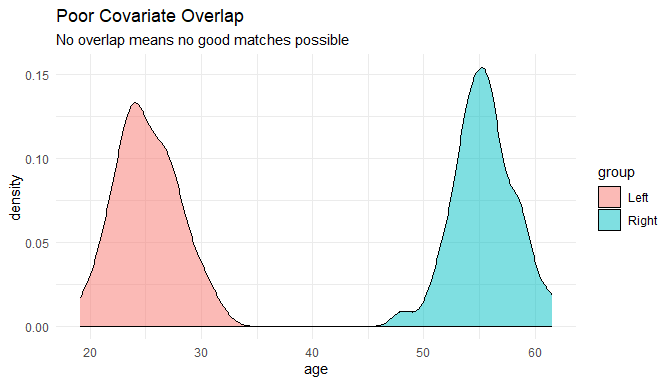

```r
# Simulate poor overlap scenario
set.seed(123)
left <- tibble(id = 1:50, age = rnorm(50, mean = 25, sd = 3))
right <- tibble(id = 1:50, age = rnorm(50, mean = 55, sd = 3))

# Visualize overlap
library(ggplot2)
combined <- bind_rows(
  left |> mutate(group = "Left"),
  right |> mutate(group = "Right")
)

ggplot(combined, aes(x = age, fill = group)) +
  geom_density(alpha = 0.5) +
  labs(title = "Poor Covariate Overlap",
       subtitle = "No overlap means no good matches possible") +
  theme_minimal() +
  theme(plot.background = element_rect(fill = "transparent", color = NA),
        panel.background = element_rect(fill = "transparent", color = NA))
```

## Poor Balance Despite Matching

### Symptom

After matching, `balance_diagnostics()` shows |std_diff| > 0.25 for some variables.

```r
# Example of poor balance
set.seed(456)
left <- tibble(
  id = 1:100,
  age = rnorm(100, 30, 5),
  income = rnorm(100, 80000, 20000)  # Very different from right
)
right <- tibble(
  id = 1:100,
  age = rnorm(100, 32, 5),
  income = rnorm(100, 40000, 10000)  # Very different income
)

result <- match_couples(left, right, vars = c("age", "income"), auto_scale = TRUE,
                        method = "hungarian")
```

```
#> Auto-selected scaling method: standardize
```

```r
balance <- balance_diagnostics(result, left, right, vars = c("age", "income"))
print(balance)
```

```
#>
#> Balance Diagnostics for Matched Pairs
#> ======================================
#>
#> Matching Summary:
#>   Method: lap
#>   Matched pairs: 100
#>   Unmatched left: 0 (of 100)
#>   Unmatched right: 0 (of 100)
#>
#> Variable-level Balance:
#> # A tibble: 2 × 7
#>   Variable `Mean Left` `Mean Right` `Mean Diff` `Std Diff` `Var Ratio` `KS Stat`
#>   <chr>          <dbl>        <dbl>       <dbl>      <dbl>       <dbl>     <dbl>
#> 1 age             30.6         32.5       -1.89     -0.386        1.10      0.22
#> 2 income       77666.       41353.     36313.        2.40         4.63      0.81
#>
#> Overall Balance:
#>   Mean |Std Diff|: 1.391 (Poor)
#>   Max |Std Diff|: 2.397
#>   Vars with |Std Diff| > 0.25: 100.0%
#>
#> Balance Interpretation:
#>   |Std Diff| < 0.10: Excellent balance
#>   |Std Diff| 0.10-0.25: Good balance
#>   |Std Diff| 0.25-0.50: Acceptable balance
#>   |Std Diff| > 0.50: Poor balance
```

### Causes

1. **Weak overlap**: Groups are too different on key variables
2. **Missing confounders**: Important variables not included in matching
3. **Caliper too loose**: Accepting poor matches
4. **Wrong scaling**: Variables not properly weighted

### Solutions

**1. Add more matching variables:**

```r
# Include additional relevant variables
result <- match_couples(
  left, right,
  vars = c("age", "income", "education", "region"),  # More variables
  auto_scale = TRUE
)
```

**2. Tighten caliper (fewer but better matches):**

```r
result_strict <- match_couples(
  left, right,
  vars = c("age", "income"),
  max_distance = 0.3,  # Stricter caliper
  auto_scale = TRUE,
  method = "hungarian"
)
```

```
#> Auto-selected scaling method: standardize
#> Warning: 99.2% of pairs are forbidden!
#>   Only 84 valid pairs for 100 left units - the matching pool is shallow!
#>   Your constraints might be critically strict.
#>   Consider:
#>     - Relaxing max_distance threshold
#>     - Widening calipers
#>     - Using fewer/broader blocks
#>     - Checking if your data actually overlaps
```

```r
cat("Original matches:", result$info$n_matched, "\n")
```

```
#> Original matches: 100
```

```r
cat("With caliper:", result_strict$info$n_matched, "\n")
```

```
#> With caliper: 23
```

```r
balance_strict <- balance_diagnostics(result_strict, left, right, vars = c("age", "income"))
print(balance_strict)
```

[output not shown]

**3. Use blocking on problematic variable:**

```r
# Block on income tertiles to ensure exact balance
left$income_cat <- cut(left$income, breaks = 3, labels = c("low", "mid", "high"))
right$income_cat <- cut(right$income, breaks = 3, labels = c("low", "mid", "high"))

blocks <- matchmaker(left, right, block_type = "group", block_by = "income_cat")
result_blocked <- match_couples(
  blocks$left, blocks$right,
  vars = c("age"),  # Match on age within income blocks
  block_id = "block_id"
)
```

**4. Try different scaling:**

```r
# Compare scaling methods
for (scale_method in c("robust", "standardize", "range")) {
  res <- match_couples(left, right, vars = c("age", "income"),
                       auto_scale = TRUE, scale = scale_method,
                       method = "hungarian")
  bal <- balance_diagnostics(res, left, right, vars = c("age", "income"))
  cat(scale_method, "- max |std_diff|:",
      round(bal$overall$max_abs_std_diff, 3), "\n")
}
```

```
#> robust - max |std_diff|: 2.397
#> standardize - max |std_diff|: 2.397
#> range - max |std_diff|: 2.397
```